# sec7 EDA answer

```r
library(tidyverse)
library(GGally)
library(gridExtra)
```

# Ex. 7.3.4

## 1

> Explore the distribution of each of the x, y, and z variables in diamonds. What do you learn? Think about a diamond and how you might decide which dimension is the length, width, and depth.

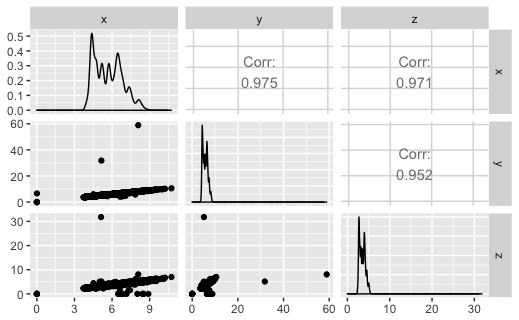

```r
ggpairs(diamonds %>% select(x,y,z))
```

ダイアモンドは円形なので一番相関の大きい`x`,`y`がlength,widthでしょう.

## 2

> Explore the distribution of price. Do you discover anything unusual or surprising? (Hint: Carefully think about the binwidth and make sure you try a wide range of values.)

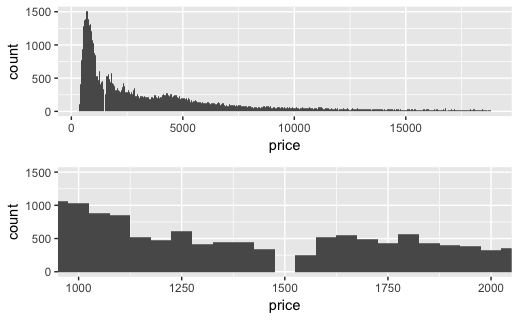

```r
grid.arrange(
ggplot(diamonds,aes(x=price))+
  geom_histogram(binwidth=50),
ggplot(diamonds,aes(x=price))+
  geom_histogram(binwidth=50)+
  coord_cartesian(xlim=c(1000,2000))
)
```

価格1500にデータが存在しない！不思議！

## 3

> How many diamonds are 0.99 carat? How many are 1 carat? What do you think is the cause of the difference?

```r
print(dim(diamonds %>% filter(carat==0.99)))
```

```
[1] 23 10
```

```r
print(dim(diamonds %>% filter(carat==1)))
```

```
[1] 1558   10
```

ちゃんとキリのいいcaratで作りたいんちゃう.

## 4

> Compare and contrast coord_cartesian() vs xlim() or ylim() when zooming in on a histogram. What happens if you leave binwidth unset? What happens if you try and zoom so only half a bar shows?

*xlim() vs coor_cartesian*

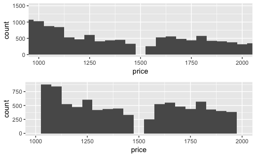

```r
grid.arrange(
ggplot(diamonds,aes(x=price))+
  geom_histogram(binwidth=50)+
  coord_cartesian(xlim=c(1000,2000)),
ggplot(diamonds,aes(x=price))+
  geom_histogram(binwidth=50)+
  xlim(c(1000,2000))
)
```

*ylim() vs coor_cartesian*

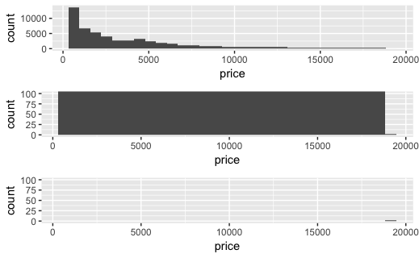

```r
grid.arrange(
ggplot(diamonds,aes(x=price))+
  geom_histogram(),
ggplot(diamonds,aes(x=price))+
  geom_histogram()+
  coord_cartesian(ylim=c(0,100)),
ggplot(diamonds,aes(x=price))+
  geom_histogram()+
  ylim(c(0,100))
)
```

この結果はかなり謎…一つ目，二つ目は妥当，なぜ`ylim`で消える？？

# Ex. 7.4.1

## 1

> What happens to missing values in a histogram? What happens to missing values in a bar chart? Why is there a difference?

まず，各列の欠測の数え方

```r
apply(X=is.na(diamonds),MARGIN=2,sum)
```

```
  carat     cut   color clarity   depth   table   price       x       y       z
      0       0       0       0       0       0       0       0       0       0
```

```r
apply(X=is.na(flights),MARGIN=2,sum)
```

```
          year          month            day       dep_time sched_dep_time
             0              0              0           8255              0
     dep_delay       arr_time sched_arr_time      arr_delay        carrier
          8255           8713              0           9430              0
        flight        tailnum         origin           dest       air_time
             0           2512              0              0           9430
      distance           hour         minute      time_hour
             0              0              0              0
```

geom_bar用にmissingあり離散列が欲しいがない(tailnumはユニークidが多い)ので無理やり作る

```r
flights2 <- flights %>%
  mutate(delay_type = if_else(dep_delay>0,'late','fast'))
```

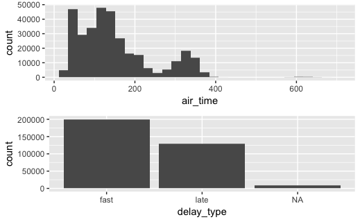

```r
p1 <- ggplot(data=flights,aes(x=air_time))+geom_histogram()
p2 <- ggplot(data=flights2,aes(x=delay_type))+geom_bar()
grid.arrange(p1,p2)
```

つまりbar plotはNAも個別のラベルとしてカウントする！！

## 2

> What does `na.rm = TRUE` do in `mean()` and `sum()`?

```r
flights %>%
  group_by(dest) %>%
  summarise(avg=mean(air_time))
```

| dest | avg |
| --- | --- |
| ABQ | 249.1693 |
| ACK | NA |
| ALB | NA |
| ANC | 413.1250 |
| ATL | NA |
| AUS | NA |
| AVL | NA |
| BDL | NA |
| BGR | NA |
| BHM | NA |

[output cut: 95 more lines]

```r
flights %>%
  group_by(dest) %>%
  summarise(avg=mean(air_time,na.rm=TRUE))
```

| dest | avg |
| --- | --- |
| ABQ | 249.16929 |
| ACK | 42.06818 |
| ALB | 31.78708 |
| ANC | 413.12500 |
| ATL | 112.93045 |
| AUS | 212.72791 |
| AVL | 89.88889 |
| BDL | 25.46602 |
| BGR | 54.11732 |
| BHM | 122.77695 |

[output cut: 95 more lines]

`NA`が一つでもあると平均や合計の結果が全て`NA`になってしまうので`na.rm=TRUE`で無視しましょう.

# Ex. 7.5.1.1

## 1

> Use what you’ve learned to improve the visualisation of the departure times of cancelled vs. non-cancelled flights.

```r
cancelled <- nycflights13::flights %>%
  mutate(
    cancelled = is.na(dep_time),
    sched_hour = sched_dep_time %/% 100,
    sched_min = sched_dep_time %% 100,
    sched_dep_time = sched_hour + sched_min/60
  ) %>%
  select(cancelled,sched_hour,sched_min,sched_dep_time)
cancelled
```

| cancelled | sched_hour | sched_min | sched_dep_time |
| --- | --- | --- | --- |
| FALSE | 5 | 15 | 5.250000 |
| FALSE | 5 | 29 | 5.483333 |
| FALSE | 5 | 40 | 5.666667 |
| FALSE | 5 | 45 | 5.750000 |
| FALSE | 6 | 0 | 6.000000 |
| FALSE | 5 | 58 | 5.966667 |
| FALSE | 6 | 0 | 6.000000 |
| FALSE | 6 | 0 | 6.000000 |
| FALSE | 6 | 0 | 6.000000 |
| FALSE | 6 | 0 | 6.000000 |

[output cut: 990 more lines]

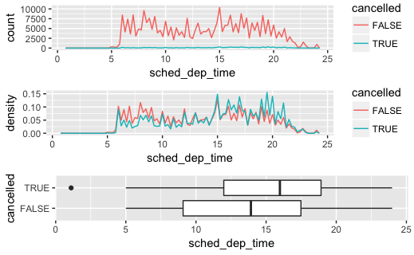

```r
p1 <- ggplot(cancelled,aes(x=sched_dep_time))+geom_freqpoly(aes(color=cancelled),binwidth=1/4)
p2 <- ggplot(cancelled,aes(x=sched_dep_time,y=..density..))+geom_freqpoly(aes(color=cancelled),binwidth=1/4)
p3 <- ggplot(cancelled,aes(x=cancelled,y=sched_dep_time))+geom_boxplot()+coord_flip()
grid.arrange(p1,p2,p3)
```

## 2

> What variable in the diamonds dataset is most important for predicting the price of a diamond? How is that variable correlated with cut? Why does the combination of those two relationships lead to lower quality diamonds being more expensive?

```r
#
```

ここちょっとむずいので後

## 3

> Install the ggstance package, and create a horizontal boxplot. How does this compare to using `coord_flip()`?

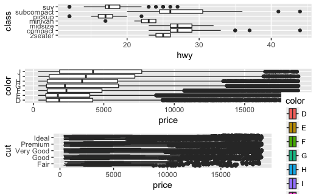

```r
library(ggstance)
p1 <- ggplot(mpg,mapping=aes(x=hwy,y=class))+geom_boxploth()
p2 <- ggplot(diamonds,mapping=aes(x=price,y=color))+geom_boxploth()
p3 <- ggplot(diamonds,mapping=aes(x=price,y=cut,fill=color))+geom_boxploth()
grid.arrange(p1,p2,p3)
```

まじで，`coord_flip()`使えばいいと思う．`x`, `y`の指定が逆になるので注意.

## 4

> One problem with boxplots is that they were developed in an era of much smaller datasets and tend to display a prohibitively large number of “outlying values”. One approach to remedy this problem is the letter value plot. Install the lvplot package, and try using geom_lv() to display the distribution of price vs cut. What do you learn? How do you interpret the plots?

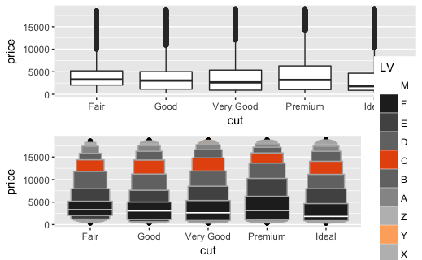

```r
library(lvplot)
grid.arrange(ggplot(diamonds)+geom_boxplot(aes(x=cut,y=price)),
ggplot(diamonds)+geom_lv(aes(x=cut,y=price,fill=..LV..))+
  scale_fill_lv()
)
```

geom_lvちょっとよくわからんな．．．

## 5

> Compare and contrast `geom_violin()` with a facetted `geom_histogram()`, or a coloured `geom_freqpoly()`. What are the pros and cons of each method?

## 6

> If you have a small dataset, it’s sometimes useful to use `geom_jitter()` to see the relationship between a continuous and categorical variable. The ggbeeswarm package provides a number of methods similar to `geom_jitter()`. List them and briefly describe what each one does.

# Ex. 7.5.2.1

## 1

> How could you rescale the count dataset above to more clearly show the distribution of cut within colour, or colour within cut?

`scale_fill_gradient()`をいじる．特に対数変換がいい気がする.

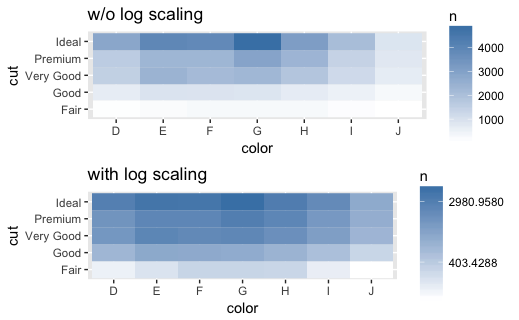

```r
grid.arrange(
diamonds%>%
  count(color,cut) %>%
  ggplot(aes(x=color,y=cut))+
  geom_tile(aes(fill=n),position = 'identity')+
  scale_fill_gradient(low='white',high='steelblue')+
  labs(title='w/o log scaling'),
diamonds%>%
  count(color,cut) %>%
  ggplot(aes(x=color,y=cut))+
  geom_tile(aes(fill=n),position = 'identity')+
  scale_fill_gradient(low='white',high='steelblue',trans='log')+
  labs(title='with log scaling')
)
```

## 2

> Use `geom_tile()` together with dplyr to explore how average flight delays vary by destination and month of year. What makes the plot difficult to read? How could you improve it?

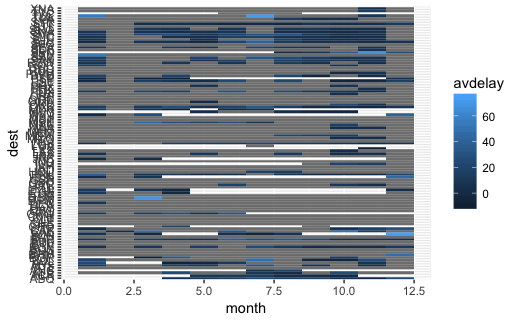

```r
library(nycflights13)
flights %>%
  group_by(dest,month) %>%
  summarise(avdelay = mean(dep_delay)) %>%
  ggplot(aes(x=dest,y=month))+
  geom_tile(aes(fill=avdelay))+
  coord_flip()
```

## 3

> Why is it slightly better to use `aes(x = color, y = cut)` rather than `aes(x = cut, y = color)` in the example above?

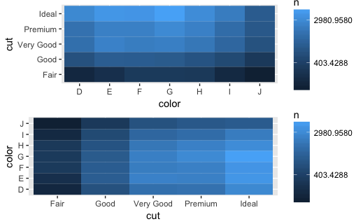

```r
grid.arrange(
diamonds%>%
  count(color,cut) %>%
  ggplot(aes(x=color,y=cut))+
  geom_tile(aes(fill=n))+
  scale_fill_gradient(trans='log'),
diamonds%>%
  count(color,cut) %>%
  ggplot(aes(x=cut,y=color))+
  geom_tile(aes(fill=n))+
  scale_fill_gradient(trans='log')
)
```

なんだろう．．．

- cutの方がvalueの文字列が長いのでy軸に置いといたほうがつぶれにくい．

くらいじゃないかな？

# Ex. 7.5.3.1

## 1

> Instead of summarising the conditional distribution with a boxplot, you could use a frequency polygon. What do you need to consider when using `cut_width()` vs `cut_number()`? How does that impact a visualisation of the 2d distribution of carat and price?

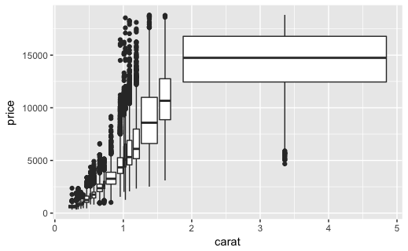

```r
ggplot(diamonds,mapping=aes(x=carat,y=price))+
  geom_boxplot(aes(group=cut_number(carat,20)))
```

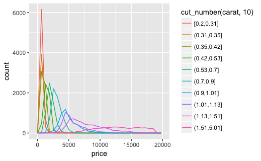

```r
ggplot(diamonds,mapping=aes(x=price))+
  geom_freqpoly(aes(color=cut_number(carat,10)))
```

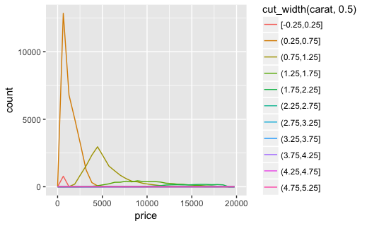

```r
ggplot(diamonds,mapping=aes(x=price))+
  geom_freqpoly(aes(color=cut_width(carat,0.5)))
```

- まぁ２番目みたいに固定幅ではなくbinの個数で指定した方がいいかもな

## 2

> Visualise the distribution of carat, partitioned by price.

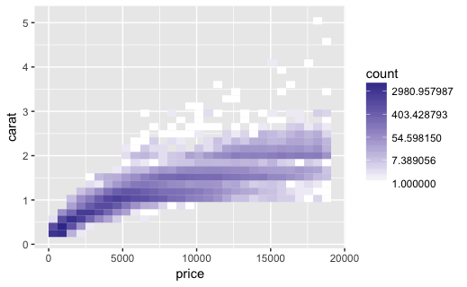

```r
ggplot(diamonds,aes(x=price,y=carat))+
  geom_bin2d()+
  scale_fill_gradient2(trans='log')
```

## 3

> How does the price distribution of very large diamonds compare to small diamonds. Is it as you expect, or does it surprise you?

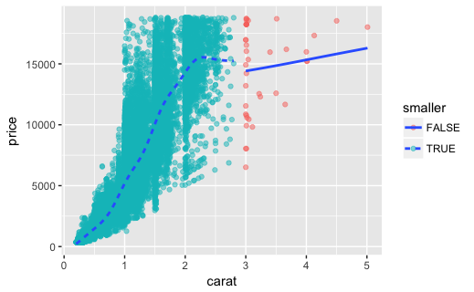

```r
diamonds4 <- diamonds %>% mutate(smaller = carat<3)%>%
  select(smaller,everything())
ggplot(data = diamonds4,aes(x=carat,y=price))+
  geom_point(aes(color=smaller),alpha=0.5)+
  geom_smooth(aes(linetype=smaller),se=FALSE)
```

## 4

> Combine two of the techniques you’ve learned to visualise the combined distribution of cut, carat, and price.

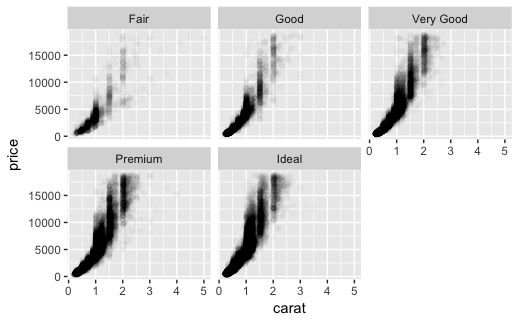

```r
ggplot(data=diamonds)+
  geom_point(aes(x=carat,y=price),alpha=1/50)+
  facet_wrap(~cut,nrow=2)
```

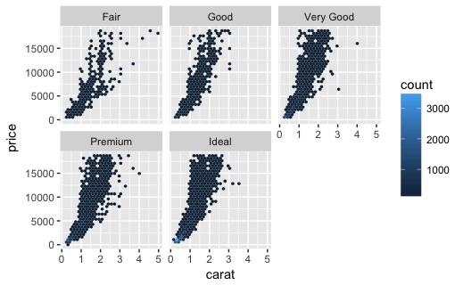

```r
ggplot(data=diamonds)+
  geom_hex(aes(x=carat,y=price))+
  facet_wrap(~cut,nrow=2) # hexとか使ったほうが軽くていいね
```

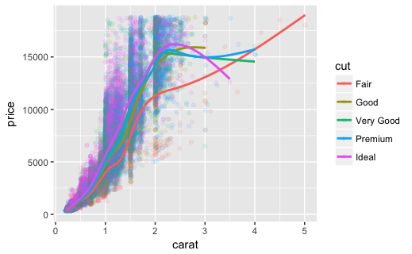

```r
ggplot(data = diamonds,aes(x=carat,y=price))+
  geom_point(aes(color=cut),alpha=0.1)+
  geom_smooth(aes(color=cut),se=FALSE)
```

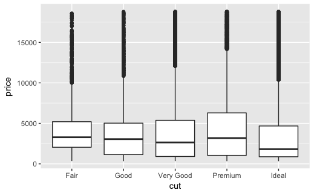

```r
# caratが同じならやはりcutが悪いほうが安い
#下だと交絡にやられてるな
ggplot(data=diamonds,aes(x=cut,y=price))+
  geom_boxplot()
```

## 5

> Two dimensional plots reveal outliers that are not visible in one dimensional plots. For example, some points in the plot below have an unusual combination of x and y values, which makes the points outliers even though their x and y values appear normal when examined separately.

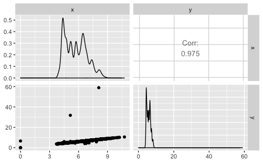

```r
ggpairs(diamonds%>%select(x,y))
```

2d plotだとある外れ値が各軸に射影するとなくなるね．